# NCDB Meningioma 2015

All

Jason Brant

December 21, 2017

**Note: To hide the code from this document, click the button in the upper right corner.**

```r
col.width <- c(37, 10, 1, 1, 3, 1, 2, 1, 2, 1, 1, 1, 1, 1, 1, 8, 2, 2, 2, 4, 4, 1, 4, 1, 1, 1, 3, 2, 2, 8,
               2, 5, 5, 5, 4, 5, 5, 5, 4, 2, 1, 2, 1, 3, 1, 1, 1, 1, 1, 1, 3, 3, 3, 3, 3, 3, 3, 3, 3, 3, 3,
               3, 3, 3, 3, 3, 3, 3, 3, 3, 3, 3, 3, 3, 3, 6, 8, 8, 8, 2, 1, 1, 1, 1, 8, 1, 1, 8, 1, 1, 2,
               2, 5, 2, 5, 3, 1, 3, 1, 8, 8, 2, 8, 2, 8, 2, 2, 1, 8, 1, 1, 1, 1, 1, 8, 1, 2, 2, 2, 2, 2,
               1, 1, 1, 2, 1)
col.names.abr <- c("PUF_CASE_ID", "PUF_FACILITY_ID", "FACILITY_TYPE_CD",  "FACILITY_LOCATION_CD", "AGE", "SEX", "RACE",
                   "SPANISH_HISPANIC_ORIGIN", "INSURANCE_STATUS", "MED_INC_QUAR_00", "NO_HSD_QUAR_00", "UR_CD_03",
                   "MED_INC_QUAR_12", "NO_HSD_QUAR_12", "UR_CD_13", "CROWFLY", "CDCC_TOTAL", "SEQUENCE_NUMBER",
                   "CLASS_OF_CASE", "YEAR_OF_DIAGNOSIS", "PRIMARY_SITE",  "LATERALITY", "HISTOLOGY", "BEHAVIOR",
                   "GRADE", "DIAGNOSTIC_CONFIRMATION", "TUMOR_SIZE", "REGIONAL_NODES_POSITIVE",
                   "REGIONAL_NODES_EXAMINED", "DX_STAGING_PROC_DAYS", "RX_SUMM_DXSTG_PROC", "TNM_CLIN_T",
                   "TNM_CLIN_N", "TNM_CLIN_M", "TNM_CLIN_STAGE_GROUP", "TNM_PATH_T", "TNM_PATH_N", "TNM_PATH_M",
                   "TNM_PATH_STAGE_GROUP", "TNM_EDITION_NUMBER", "ANALYTIC_STAGE_GROUP", "CS_METS_AT_DX",
                   "CS_METS_EVAL", "CS_EXTENSION", "CS_TUMOR_SIZEEXT_EVAL", "CS_METS_DX_BONE",
                   "CS_METS_DX_BRAIN", "CS_METS_DX_LIVER", "CS_METS_DX_LUNG", "LYMPH_VASCULAR_INVASION",
                   "CS_SITESPECIFIC_FACTOR_1", "CS_SITESPECIFIC_FACTOR_2", "CS_SITESPECIFIC_FACTOR_3",
                   "CS_SITESPECIFIC_FACTOR_4", "CS_SITESPECIFIC_FACTOR_5", "CS_SITESPECIFIC_FACTOR_6",
                   "CS_SITESPECIFIC_FACTOR_7", "CS_SITESPECIFIC_FACTOR_8", "CS_SITESPECIFIC_FACTOR_9",
                   "CS_SITESPECIFIC_FACTOR_10", "CS_SITESPECIFIC_FACTOR_11", "CS_SITESPECIFIC_FACTOR_12",
                   "CS_SITESPECIFIC_FACTOR_13", "CS_SITESPECIFIC_FACTOR_14", "CS_SITESPECIFIC_FACTOR_15",
                   "CS_SITESPECIFIC_FACTOR_16", "CS_SITESPECIFIC_FACTOR_17", "CS_SITESPECIFIC_FACTOR_18",
                   "CS_SITESPECIFIC_FACTOR_19", "CS_SITESPECIFIC_FACTOR_20", "CS_SITESPECIFIC_FACTOR_21",
                   "CS_SITESPECIFIC_FACTOR_22", "CS_SITESPECIFIC_FACTOR_23", "CS_SITESPECIFIC_FACTOR_24",
                   "CS_SITESPECIFIC_FACTOR_25", "CS_VERSION_LATEST", "DX_RX_STARTED_DAYS",
                   "DX_SURG_STARTED_DAYS", "DX_DEFSURG_STARTED_DAYS", "RX_SUMM_SURG_PRIM_SITE",
                   "RX_HOSP_SURG_APPR_2010", "RX_SUMM_SURGICAL_MARGINS", "RX_SUMM_SCOPE_REG_LN_SUR",
                   "RX_SUMM_SURG_OTH_REGDIS", "SURG_DISCHARGE_DAYS", "READM_HOSP_30_DAYS",
                   "REASON_FOR_NO_SURGERY", "DX_RAD_STARTED_DAYS", "RX_SUMM_RADIATION", "RAD_LOCATION_OF_RX",
                   "RAD_TREAT_VOL", "RAD_REGIONAL_RX_MODALITY", "RAD_REGIONAL_DOSE_CGY",
                   "RAD_BOOST_RX_MODALITY", "RAD_BOOST_DOSE_CGY", "RAD_NUM_TREAT_VOL",
                   "RX_SUMM_SURGRAD_SEQ", "RAD_ELAPSED_RX_DAYS", "REASON_FOR_NO_RADIATION",
                   "DX_SYSTEMIC_STARTED_DAYS", "DX_CHEMO_STARTED_DAYS", "RX_SUMM_CHEMO",
                   "DX_HORMONE_STARTED_DAYS", "RX_SUMM_HORMONE", "DX_IMMUNO_STARTED_DAYS",
                   "RX_SUMM_IMMUNOTHERAPY", "RX_SUMM_TRNSPLNT_ENDO", "RX_SUMM_SYSTEMIC_SUR_SEQ",
                   "DX_OTHER_STARTED_DAYS", "RX_SUMM_OTHER", "PALLIATIVE_CARE", "RX_SUMM_TREATMENT_STATUS",
                   "PUF_30_DAY_MORT_CD", "PUF_90_DAY_MORT_CD", "DX_LASTCONTACT_DEATH_MONTHS",
                   "PUF_VITAL_STATUS", "RX_HOSP_SURG_PRIM_SITE", "RX_HOSP_CHEMO", "RX_HOSP_IMMUNOTHERAPY",
                   "RX_HOSP_HORMONE", "RX_HOSP_OTHER", "PUF_MULT_SOURCE", "REFERENCE_DATE_FLAG",
                   "RX_SUMM_SCOPE_REG_LN_2012", "RX_HOSP_DXSTG_PROC", "PALLIATIVE_CARE_HOSP")
#Read in data for each subsite
bone.joint <- read_fwf('I:/Brant/Research/NCDB/Data/Data_2017/NCDB_PUF_DATA_Nov-07-2017/NCDBPUF_BoneJont.3.2015.0.dat',
                       fwf_widths(col.width, col_names = col.names.abr),
                       col_types = cols(.default = col_character()))
brain <- read_fwf('I:/Brant/Research/NCDB/Data/Data_2017/NCDB_PUF_DATA_Nov-07-2017/NCDBPUF_Brain.3.2015.0.dat',
                       fwf_widths(col.width, col_names = col.names.abr),
                       col_types = cols(.default = col_character()))
cns <- read_fwf('I:/Brant/Research/NCDB/Data/Data_2017/NCDB_PUF_DATA_Nov-07-2017/NCDBPUF_CNS.3.2015.0.dat',
                       fwf_widths(col.width, col_names = col.names.abr),
                       col_types = cols(.default = col_character()))
gum.ot.mth <- read_fwf('I:/Brant/Research/NCDB/Data/Data_2017/NCDB_PUF_DATA_Nov-07-2017/NCDBPUF_GumOtMth.3.2015.0.dat',
                       fwf_widths(col.width, col_names = col.names.abr),
                       col_types = cols(.default = col_character()))
hypophar <- read_fwf('I:/Brant/Research/NCDB/Data/Data_2017/NCDB_PUF_DATA_Nov-07-2017/NCDBPUF_Hypophar.3.2015.0.dat',
                       fwf_widths(col.width, col_names = col.names.abr),
                       col_types = cols(.default = col_character()))
larynx <- read_fwf('I:/Brant/Research/NCDB/Data/Data_2017/NCDB_PUF_DATA_Nov-07-2017/NCDBPUF_Larynx.3.2015.0.dat',
                       fwf_widths(col.width, col_names = col.names.abr),
                       col_types = cols(.default = col_character()))
lip <- read_fwf('I:/Brant/Research/NCDB/Data/Data_2017/NCDB_PUF_DATA_Nov-07-2017/NCDBPUF_Lip.3.2015.0.dat',
                       fwf_widths(col.width, col_names = col.names.abr),
                       col_types = cols(.default = col_character()))
melanoma <- read_fwf('I:/Brant/Research/NCDB/Data/Data_2017/NCDB_PUF_DATA_Nov-07-2017/NCDBPUF_Melanoma.3.2015.0.dat',
                       fwf_widths(col.width, col_names = col.names.abr),
                       col_types = cols(.default = col_character()))
fom <- read_fwf('I:/Brant/Research/NCDB/Data/Data_2017/NCDB_PUF_DATA_Nov-07-2017/NCDBPUF_MouthFlr.3.2015.0.dat',
                       fwf_widths(col.width, col_names = col.names.abr),
                       col_types = cols(.default = col_character()))
nasal <- read_fwf('I:/Brant/Research/NCDB/Data/Data_2017/NCDB_PUF_DATA_Nov-07-2017/NCDBPUF_Nasal.3.2015.0.dat',
                       fwf_widths(col.width, col_names = col.names.abr),
                       col_types = cols(.default = col_character()))
nasophar <- read_fwf('I:/Brant/Research/NCDB/Data/Data_2017/NCDB_PUF_DATA_Nov-07-2017/NCDBPUF_Nasophar.3.2015.0.dat',
                       fwf_widths(col.width, col_names = col.names.abr),
                       col_types = cols(.default = col_character()))
orophar <- read_fwf('I:/Brant/Research/NCDB/Data/Data_2017/NCDB_PUF_DATA_Nov-07-2017/NCDBPUF_Orophary.3.2015.0.dat',
                       fwf_widths(col.width, col_names = col.names.abr),
                       col_types = cols(.default = col_character()))
oth.endo <- read_fwf('I:/Brant/Research/NCDB/Data/Data_2017/NCDB_PUF_DATA_Nov-07-2017/NCDBPUF_OtEndocr.3.2015.0.dat',
                       fwf_widths(col.width, col_names = col.names.abr),
                       col_types = cols(.default = col_character()))
skin <- read_fwf('I:/Brant/Research/NCDB/Data/Data_2017/NCDB_PUF_DATA_Nov-07-2017/NCDBPUF_OtSkin.3.2015.0.dat',
                       fwf_widths(col.width, col_names = col.names.abr),
                       col_types = cols(.default = col_character()))
pharynx <- read_fwf('I:/Brant/Research/NCDB/Data/Data_2017/NCDB_PUF_DATA_Nov-07-2017/NCDBPUF_Pharynx.3.2015.0.dat',
                       fwf_widths(col.width, col_names = col.names.abr),
                       col_types = cols(.default = col_character()))
saliv.gland <- read_fwf('I:/Brant/Research/NCDB/Data/Data_2017/NCDB_PUF_DATA_Nov-07-2017/NCDBPUF_SalivGld.3.2015.0.dat',
                       fwf_widths(col.width, col_names = col.names.abr),
                       col_types = cols(.default = col_character()))
thyroid <- read_fwf('I:/Brant/Research/NCDB/Data/Data_2017/NCDB_PUF_DATA_Nov-07-2017/NCDBPUF_Thyroid.3.2015.0.dat',
                       fwf_widths(col.width, col_names = col.names.abr),
                       col_types = cols(.default = col_character()))
tongue <- read_fwf('I:/Brant/Research/NCDB/Data/Data_2017/NCDB_PUF_DATA_Nov-07-2017/NCDBPUF_Tongue.3.2015.0.dat',
                       fwf_widths(col.width, col_names = col.names.abr),
                       col_types = cols(.default = col_character()))
tonsil <- read_fwf('I:/Brant/Research/NCDB/Data/Data_2017/NCDB_PUF_DATA_Nov-07-2017/NCDBPUF_Tonsil.3.2015.0.dat',
                       fwf_widths(col.width, col_names = col.names.abr),
                       col_types = cols(.default = col_character()))
trach.med <- read_fwf('I:/Brant/Research/NCDB/Data/Data_2017/NCDB_PUF_DATA_Nov-07-2017/NCDBPUF_TrachMed.3.2015.0.dat',
                       fwf_widths(col.width, col_names = col.names.abr),
                       col_types = cols(.default = col_character()))
#Combine data for all subsites
dat <- bind_rows(bone.joint, brain, cns, gum.ot.mth, hypophar, larynx, lip, melanoma, fom, nasal, nasophar, orophar,
                 oth.endo, skin, pharynx, saliv.gland, thyroid, tongue, tonsil, trach.med)
rm(bone.joint, brain, cns, gum.ot.mth, hypophar, larynx, lip, melanoma, fom, nasal, nasophar, orophar,
                 oth.endo, skin, pharynx, saliv.gland, thyroid, tongue, tonsil, trach.med)
prim_site_text <- data_frame(PRIMARY_SITE = c("C030", "C031", "C062", "C039", "C050", "C051", "C052", "C058", "C059", "C068",
               "C069", "C060", "C061", "C129", "C130", "C131", "C132", "C138", "C139", "C320",
               "C321", "C322", "C323", "C328", "C329", "C000", "C003", "C001", "C004", "C006",
               "C002", "C005", "C008", "C009", "C440", "C442", "C443", "C444", "C445", "C446",
               "C447", "C448", "C449", "C441", "C040", "C041", "C048", "C049", "C300", "C301",
               "C310", "C311", "C312", "C313", "C318", "C319", "C110", "C111", "C112", "C113",
               "C118", "C119", "C090", "C091", "C098", "C099", "C100", "C102", "C103", "C104",
               "C108", "C109", "C101", "C140", "C142", "C148", "C079", "C080", "C081", "C088",
               "C089", "C739", "C019", "C024", "C020", "C021", "C022", "C023", "C028", "C029"),
               SITE_TEXT = c("C03.0: Gum, upper", "C03.1 Gum, lower", "C06.2 Retromolar area", "C03.9 Gum, NOS",
               "C05.0 Hard Palate", "C05.1 Soft Palate", "C05.2 Uvula", "C05.8 Overlapping lesion of palate",
               "C05.9 Palate NOS", "C06.8 Overlapping lesion of other an unspecified parts of mouth",
               "C06.9 Mouth, NOS", "C06.0 Buccal mucosa", "C06.1 Vestibule of mouth", "C12.9  Pyriform sinus",
               "C13.0  Postcricoid region", "C13.1  Hypopharyngeal aspect of aryepiglottic fold",
               "C13.2  Posterior wall of hypopharynx", "C13.8  Overlapping lesion of hypopharynx",
               "C13.9  Hypopharynx, NOS (laryngopharynx)", "C32.0  Glottis", "C32.1  Supraglottis",
               "C32.2  Subglottis", "C32.3  Laryngeal cartilage", "C32.8  Overlapping lesion of larynx",
               "C32.9  Larynx, NOS", "C00.0  External upper lip (vermilion)", "C00.3  Mucosa of upper lip",
               "C00.1  External lower lip (vermilion)", "C00.4  Mucosa of lower lip", "C00.6  Commissure of lip",
               "C00.2  External lip, NOS (vermilion)", "C00.5  Mucosa of lip, NOS", "C00.8  Overlapping lesion of lip",
               "C00.9  Lip, NOS (excludes skin of lip C44.0)", "C44.0  Skin of lip, NOS", "C44.2  External ear",
               "C44.3  Skin of other and unspecified parts of face", "C44.4  Skin of scalp and neck",
               "C44.5  Skin of trunk", "C44.6  Skin of upper limb and shoulder", "C44.7  Skin of lower limb and hip",
               "C44.8  Overlapping lesion of skin", "C44.9  Skin, NOS", "C44.1 Eyelid",
```

```r
               "C04.0  Anterior floor of mouth", "C04.1  Lateral floor of mouth", "C04.8  Overlapping lesion of floor of mouth",
               "C04.9  Floor of mouth, NOS", "C30.0  Nasal cavity (excluding nose, NOS C76.0)", "C30.1  Middle ear",
               "C31.0  Maxillary sinus", "C31.1  Ethmoid sinus", "C31.2  Frontal sinus", "C31.3  Sphenoid sinus",
               "C31.8  Overlapping lesion of accessory sinuses", "C31.9  Accessory sinus, NOS",
               "C11.0  Superior wall of nasopharynx", "C11.1  Posterior wall of nasopharynx (excluding pharyngeal tonsil)",
               "C11.2  Lateral wall of nasopharynx", "C11.3  Anterior wall of nasopharynx",
               "C11.8  Overlapping lesion of nasopharynx", "C11.9  Nasopharynx, NOS", "C09.0  Tonsillar fossa",
               "C09.1  Tonsillar pillar", "C09.8  Overlapping lesion of tonsil",
               "C09.9  Tonsil, NOS (excluding lingual tonsil C02.4)", "C10.0  Vallecula",
               "C10.2  Lateral wall of oropharynx", "C10.3  Posterior wall of oropharynx",
               "C10.4  Branchial cleft (site of neoplasm)", "C10.8  Overlapping lesion of oropharynx",
               "C10.9  Oropharynx, NOS", "C10.1  Anterior surface of epiglottis", "C14.0  Pharynx, NOS",
               "C14.2  Waldeyer ring", "C14.8  Overlapping lesion of lip, oral cavity", "C07.9  Parotid gland",
               "C08.0  Submandibular gland", "C08.1  Sublingual gland", "C08.8  Overlapping lesion of major salivary glands",
               "C08.9  Major salivary gland, NOS", "C73.9  Thyroid gland", "C01.9  Base of tongue, NOS",
               "C02.4  Lingual tonsil", "C02.0  Dorsal surface of tongue, NOS", "C02.1  Border of tongue (Tip)",
               "C02.2  Ventral surface of tongue, NOS", "C02.3  Anterior 2/3 of tongue, NOS",
               "C02.8  Overlapping lesion of tongue", "C02.9  Tongue, NOS"),
               CS_GROUP = c("gum_upper", "gum_lower", "gum_lower", "gum_nos", "hard_palate", "soft_palate",
             "soft_palate", "other_mouth", "other_mouth", "other_mouth", "other_mouth",
             "buccal", "buccal", "hypopharynx", "hypopharynx", "hypopharynx", "hypopharynx",
             "hypopharynx", "hypopharynx", "glottis", "supraglot", "subglot", "lx_oth",
             "lx_oth", "lx_oth", "up_lip", "up_lip", "low_lip", "low_lip", "low_lip",
             "lip_oth", "lip_oth", "lip_oth", "lip_oth", "skin", "skin", "skin", "skin",
             "skin", "skin", "skin", "skin", "skin", "eyelid", "fom", "fom", "fom", "fom",
             "nasal_cavity", "mid_ear", "max_sin", "eth_sin", "oth_sin", "oth_sin",
             "oth_sin", "oth_sin", "np", "np", "np", "np", "np", "np", "op",
             "op", "op", "op", "op", "op", "op", "op", "op", "op", "ant_epi",
             "oth_phary", "oth_phary", "oth_phary", "parotid", "smglnd",
             "glnd_oth", "glnd_oth", "glnd_oth", "thyroid", "bot_lt",
             "bot_lt", "tongue_oth", "tongue_oth", "tongue_oth", "tongue_oth",
             "tongue_oth", "tongue_oth"))
dat <- merge(dat, prim_site_text, by = "PRIMARY_SITE", all.x = TRUE)
rm(prim_site_text)
fact_vars <- c("PRIMARY_SITE", "FACILITY_TYPE_CD", "FACILITY_LOCATION_CD", "SEX", "RACE", "SPANISH_HISPANIC_ORIGIN",
               "INSURANCE_STATUS", "MED_INC_QUAR_00", "NO_HSD_QUAR_00", "UR_CD_03", "MED_INC_QUAR_12",
               "NO_HSD_QUAR_12", "UR_CD_13", "CDCC_TOTAL", "SEQUENCE_NUMBER", "CLASS_OF_CASE",
               "YEAR_OF_DIAGNOSIS", "LATERALITY", "HISTOLOGY", "BEHAVIOR",
               "GRADE", "DIAGNOSTIC_CONFIRMATION", "REGIONAL_NODES_POSITIVE", "REGIONAL_NODES_EXAMINED",
               "RX_SUMM_DXSTG_PROC", "TNM_CLIN_T",
               "TNM_CLIN_N", "TNM_CLIN_M", "TNM_CLIN_STAGE_GROUP", "TNM_PATH_T", "TNM_PATH_N",
               "TNM_PATH_M", "TNM_PATH_STAGE_GROUP", "TNM_EDITION_NUMBER", "ANALYTIC_STAGE_GROUP",
               "CS_METS_AT_DX", "CS_METS_EVAL", "CS_EXTENSION", "CS_TUMOR_SIZEEXT_EVAL", "CS_METS_DX_BONE",
               "CS_METS_DX_BRAIN", "CS_METS_DX_LIVER", "CS_METS_DX_LUNG", "LYMPH_VASCULAR_INVASION",
               "CS_VERSION_LATEST", "RX_SUMM_SURG_PRIM_SITE", "RX_HOSP_SURG_APPR_2010", "RX_SUMM_SURGICAL_MARGINS",
               "RX_SUMM_SCOPE_REG_LN_SUR", "RX_SUMM_SURG_OTH_REGDIS", "READM_HOSP_30_DAYS", "REASON_FOR_NO_SURGERY",
               "RX_SUMM_RADIATION",
               "RAD_LOCATION_OF_RX", "RAD_TREAT_VOL", "RAD_REGIONAL_RX_MODALITY", "RAD_BOOST_RX_MODALITY",
               "RX_SUMM_SURGRAD_SEQ", "REASON_FOR_NO_RADIATION", "RX_SUMM_CHEMO", "RX_SUMM_HORMONE",
               "RX_SUMM_IMMUNOTHERAPY", "RX_SUMM_TRNSPLNT_ENDO", "RX_SUMM_SYSTEMIC_SUR_SEQ",
               "RX_SUMM_OTHER", "PALLIATIVE_CARE", "RX_SUMM_TREATMENT_STATUS", "PUF_30_DAY_MORT_CD",
               "PUF_90_DAY_MORT_CD", "RX_HOSP_SURG_PRIM_SITE", "RX_HOSP_CHEMO", "RX_HOSP_IMMUNOTHERAPY",
               "RX_HOSP_HORMONE", "RX_HOSP_OTHER", "PUF_MULT_SOURCE", "REFERENCE_DATE_FLAG",
               "RX_SUMM_SCOPE_REG_LN_2012",   'RX_HOSP_DXSTG_PROC', 'PALLIATIVE_CARE_HOSP')
dat[fact_vars] <- lapply(dat[fact_vars], as.character)
dat[fact_vars] <- lapply(dat[fact_vars], as.factor)
num_vars <- c("AGE", "CROWFLY", "TUMOR_SIZE", "DX_STAGING_PROC_DAYS", "DX_RX_STARTED_DAYS", "DX_SURG_STARTED_DAYS",
              "DX_DEFSURG_STARTED_DAYS", "SURG_DISCHARGE_DAYS", "DX_RAD_STARTED_DAYS",  "RAD_REGIONAL_DOSE_CGY",
              "RAD_BOOST_DOSE_CGY", "RAD_ELAPSED_RX_DAYS", "DX_SYSTEMIC_STARTED_DAYS", "DX_CHEMO_STARTED_DAYS",
              "DX_HORMONE_STARTED_DAYS", "DX_OTHER_STARTED_DAYS", "DX_LASTCONTACT_DEATH_MONTHS",
              "RAD_NUM_TREAT_VOL")
dat[num_vars] <- lapply(dat[num_vars], as.numeric)
```

```r
p_table <- function(tab_data, ...) {
  tab_data_2 <- deparse(substitute(tab_data))

  table_p <- do.call(CreateTableOne,
                     list(data = as.name(tab_data_2), includeNA = TRUE, ...))
  table_p_out <- print(table_p,
                       showAllLevels = TRUE,
                       printToggle = FALSE)
  kable(table_p_out,
        align = "c")
}
```

# Data

```r
site_code <- c("All")
histo_code <- c("9530")
behavior_code <- c("All")
data <- dat %>%
        #filter(BEHAVIOR %in% behavior_code) %>%
        #filter(PRIMARY_SITE %in% site_code) %>%
        filter(HISTOLOGY %in% histo_code) %>%
        filter(is.na(PUF_VITAL_STATUS) == FALSE) %>%
        filter(is.na(DX_LASTCONTACT_DEATH_MONTHS) == FALSE)
```

Patients were excluded if they didn’t have values for either follow up or vital status.

Patients were excluded if they had surgery to a distant site using `RX_SUMM_SURG_OTH_REGDIS`. This was done to avoid confounding of different surgical procedures. We are only interested in surgery at the primary site. These distant site surgeries were being counted in the surgery/radiation sequence and thus to simplify analysis they were removed.

```r
data %>%
        CreateTableOne(data = .,
                     vars = c("RX_SUMM_SURG_OTH_REGDIS"),
                     includeNA = TRUE) %>%
        print(.,
              showAllLevels = TRUE)
```

```
                              level Overall
  n                                 166142
  RX_SUMM_SURG_OTH_REGDIS (%) 0     162222 (97.6)
                              1        120 ( 0.1)
                              2        116 ( 0.1)
                              3         10 ( 0.0)
                              4         25 ( 0.0)
                              5          7 ( 0.0)
                              9       3642 ( 2.2)
```

```r
data <- data %>%
        filter(RX_SUMM_SURG_OTH_REGDIS == "0")
```

Whether radiation was performed was based on the `REASON_FOR_NO_RADIATION` variable. The `RADIATION_YN` variable was classified as ‘Yes’, ‘No’, or ‘Unknown’.

```r
data <- data %>%
        mutate(FACILITY_TYPE_F = fct_recode(FACILITY_TYPE_CD,
                                            "Community Cancer Program" = "1",
                                            "Comprehensive Comm Ca Program" = "2",
                                            "Academic/Research Program" = "3",
                                            "Integrated Network Ca Program" = "4",
                                            "Other" = "9")) %>%
        mutate(FACILITY_LOCATION_F = fct_recode(FACILITY_LOCATION_CD,
                                            "New England" = "1",
                                            "Middle Atlantic" = "2",
                                            "South Atlantic" = "3",
                                            "East North Central" = "4",
                                            "East South Central" = "5",
                                            "West North Central" = "6",
                                            "West South Central" = "7",
                                            "Mountain" = "8",
                                            "Pacific" = "9",
                                            "out of US" = "0")) %>%
        mutate(FACILITY_GEOGRAPHY = fct_collapse(FACILITY_LOCATION_CD,
                                                 "Northeast" = c("1", "2"),
                                                 "South" = c("3", "7"),
                                                 "Midwest" = c("4", "5", "6"),
                                                 "West" = c("8", "9"))) %>%
        mutate(AGE_F = cut(AGE, c(0, 54, 64, 74, 100))) %>%
        mutate(AGE_40 = cut(AGE, c(0, 40, 100))) %>%
        mutate(SEX_F = fct_recode(SEX,
                                "Male" = "1",
                                "Female" = "2")) %>%
        mutate(RACE_F = fct_collapse(RACE,
                                "White" = c("01"),
                                "Black" = c("02"),
                                "Asian" = c("04", "05", "06", "07", "08", "10", "11", "12", "13", "14", "15",
                                            "16", "17", "20", "21", "22", "25", "26", "27", "28", "30", "31",
                                            "32", "96", "97"),
                                "Other/Unk" = c("03", "98", "99"))) %>%
        mutate(HISPANIC = fct_collapse(SPANISH_HISPANIC_ORIGIN,
                                       "Yes" = c("1", "2", "3", "4", "5", "6", "7", "8"),
                                       "No" = c("0"),
                                       "Unknown" = c("9"))) %>%
        mutate(INSURANCE_F = fct_recode(INSURANCE_STATUS,
                                         "None" = "0",
                                         "Private" = "1",
                                         "Medicaid" = "2",
                                         "Medicare" = "3",
                                         "Other Government" = "4",
                                         "Unknown" = "9")) %>%
        mutate(INSURANCE_F = fct_relevel(INSURANCE_F,
                                         "Private")) %>%
        mutate(INCOME_F = fct_recode(MED_INC_QUAR_12,
                                      "Less than $38,000" = "1",
                                      "$38,000 - $47,999" = "2",
                                      "$48,000 - $62,999" = "3",
                                      "$63,000 +" = "4")) %>%
        mutate(EDUCATION_F = fct_recode(NO_HSD_QUAR_12,
                                        "21% or more" = "1",
                                        "13 - 20.9%" = "2",
                                        "7 - 12.9%" = "3",
                                        "Less than 7%" = "4")) %>%
        mutate(U_R_F = fct_collapse(UR_CD_13,
                                    "Metro" = c("1", "2", "3"),
                                    "Urban" = c("4", "5", "6", "7"),
                                    "Rural" = c("8", "9"))) %>%
        mutate(CLASS_OF_CASE_F = fct_collapse(CLASS_OF_CASE,
                                              All_Part_Prim = c("10", "11", "12", "13",
                                                                "14", "20", "21", "22"),
                                              Other_Facility = c("00"))) %>%
        mutate(GRADE_F = fct_recode(GRADE,
                                  "Gr I: Well Diff" = "1",
                                  "Gr II: Mod Diff" = "2",
                                  "Gr III: Poor Diff" = "3",
                                  "Gr IV: Undiff/Anaplastic" = "4",
                                  "NA/Unkown" = "9")) %>%
        mutate(HISTOLOGY_F = fct_infreq(HISTOLOGY)) %>%
        mutate(HISTOLOGY_F = factor(HISTOLOGY_F)) %>%
        mutate(HISTOLOGY_F_LIM = fct_lump(HISTOLOGY_F, prop = 0.05)) %>%
        mutate(TNM_CLIN_T = fct_recode(TNM_CLIN_T,
                                       "N_A" = "88")) %>%
        mutate(TNM_CLIN_T = fct_relevel(TNM_CLIN_T,
                                        "1")) %>%
        mutate(TNM_CLIN_N = fct_recode(TNM_CLIN_N,
                                       "N_A" = "88")) %>%
        mutate(TNM_CLIN_M = fct_recode(TNM_CLIN_M,
                                       "N_A" = "88")) %>%
        mutate(TNM_PATH_T = fct_recode(TNM_PATH_T,
                                       "N_A" = "88")) %>%
        mutate(TNM_PATH_T = fct_relevel(TNM_PATH_T,
                                        "1")) %>%
        mutate(TNM_PATH_N = fct_recode(TNM_PATH_N,
                                       "N_A" = "88")) %>%
        mutate(TNM_PATH_M = fct_recode(TNM_PATH_M,
                                       "N_A" = "88")) %>%
        mutate(TNM_CLIN_STAGE_GROUP = fct_recode(TNM_CLIN_STAGE_GROUP,
                                       "N_A" = "88")) %>%
        mutate(TNM_PATH_STAGE_GROUP = fct_recode(TNM_PATH_STAGE_GROUP,
                                       "N_A" = "88")) %>%
        mutate(MARGINS = fct_recode(RX_SUMM_SURGICAL_MARGINS,
                                    "No Residual" = "0",
                                    "Residual, NOS" = "1",
                                    "Microscopic Resid" = "2",
                                    "Macroscopic Resid" = "3",
                                    "Not evaluable" = "7",
                                    "No surg" = "8",
                                    "Unknown" = "9")) %>%
        mutate(MARGINS_YN = fct_collapse(RX_SUMM_SURGICAL_MARGINS,
                                         "Yes" = c("1", "2", "3"),
                                         "No" = c("0"),
                                         "No surg/Unk/NA" = c("7", "8", "9"))) %>%
        mutate(READM_HOSP_30_DAYS_F = fct_recode(READM_HOSP_30_DAYS,
                                                 "No_Surg_or_No_Readmit" = "0",
                                                 "Unplan_Readmit_Same" = "1",
                                                 "Plan_Readmit_Same" = "2",
                                                 "PlanUnplan_Same" = "3",
                                                 "Unknown" = "4")) %>%
        mutate(RX_SUMM_RADIATION_F = fct_recode(RX_SUMM_RADIATION,
                                                "None" = "0",
                                                "Beam Radiation" = "1",
                                                "Radioactive Implants" = "2",
                                                "Radioisotopes" = "3",
                                                "Beam + Imp or Isotopes" = "4",
                                                "Radiation, NOS" = "5",
                                                "Unknown" = "9")) %>%
        mutate(PUF_30_DAY_MORT_CD_F = fct_recode(PUF_30_DAY_MORT_CD,
                                                 "Alive_30" = "0",
                                                 "Dead_30" = "1",
                                                 "Unknown" = "9")) %>%
        mutate(PUF_90_DAY_MORT_CD_F = fct_recode(PUF_90_DAY_MORT_CD,
                                                 "Alive_90" = "0",
                                                 "Dead_90" = "1",
                                                 "Unknown" = "9")) %>%
        mutate(LYMPH_VASCULAR_INVASION_F = fct_recode(LYMPH_VASCULAR_INVASION,
                                                      "Neg_LymphVasc_Inv" = "0",
                                                      "Pos_LumphVasc_Inv" = "1",
                                                      "N_A" = "8",
                                                      "Unknown" = "9")) %>%
        mutate(RX_HOSP_SURG_APPR_2010_F = fct_recode(RX_HOSP_SURG_APPR_2010,
                                                     "No_Surg" = "0",
                                                     "Robot_Assist" = "1",
                                                     "Robot_to_Open" = "2",
                                                     "Endo_Lap" = "3",
                                                     "Endo_Lap_to_Open" = "4",
                                                     "Open_Unknown" = "5",
                                                     "Unknown" = "9")) %>%
        mutate(All = "All") %>%
        mutate(All = factor(All)) %>%
        mutate(REASON_FOR_NO_SURGERY_F = fct_recode(REASON_FOR_NO_SURGERY,
                                                    "Surg performed" = "0",
                                                    "Surg not recommended" = "1",
                                                    "No surg due to pt factors" = "2",
                                                    "No surg, pt died" = "5",
                                                    "Surg rec, not done" = "6",
                                                    "Surg rec, pt refused" = "7",
                                                    "Surg rec, unk if done" = "8",
                                                    "Unknown" = "9")) %>%
        mutate(SURGERY_YN = ifelse(REASON_FOR_NO_SURGERY == "0",
                                   "Yes",
                                   ifelse(REASON_FOR_NO_SURGERY == "9",
                                          "Ukn",
                                          "No"))) %>%
        mutate(REASON_FOR_NO_RADIATION_F = fct_recode(REASON_FOR_NO_RADIATION,
                                                    "Rad performed" = "0",
                                                    "Rad not recommended" = "1",
                                                    "No Rad due to pt factors" = "2",
                                                    "No Rad, pt died" = "5",
                                                    "Rad rec, not done" = "6",
                                                    "Rad rec, pt refused" = "7",
                                                    "Rad rec, unk if done" = "8",
                                                    "Unknown" = "9")) %>%
        mutate(RADIATION_YN = ifelse(REASON_FOR_NO_RADIATION == "0",
                                   "Yes",
                                   ifelse(REASON_FOR_NO_RADIATION == "9",
                                          "Ukn",
                                          "No"))) %>%
        mutate(SURGRAD_SEQ_F = fct_recode(RX_SUMM_SURGRAD_SEQ,
                                                   "None or Surg or Rad" = "0",
                                                   "Rad before Surg" = "2",
                                                   "Surg before Rad" = "3",
                                                   "Rad before and after Surg" = "4",
                                                   "Intraop Rad" = "5",
                                                   "Intraop Rad plus other" = "6",
                                                   "Unknown" = "9")) %>%
        mutate(SURG_RAD_SEQ = ifelse(SURGERY_YN == "Yes" & RX_SUMM_SURGRAD_SEQ == "0",
```

```r
                                     "Surg Alone",
                                     ifelse(RADIATION_YN == "Yes" & RX_SUMM_SURGRAD_SEQ == "0",
                                            "Rad Alone",
                                            ifelse(SURGERY_YN == "No" & RADIATION_YN == "No" & RX_SUMM_SURGRAD_SEQ == "0",
                                                   "No Treatement",
                                                   ifelse(RX_SUMM_SURGRAD_SEQ == "2",
                                                          "Rad then Surg",
                                                          ifelse(RX_SUMM_SURGRAD_SEQ == "3",
                                                                 "Surg then Rad",
                                                                 ifelse(RX_SUMM_SURGRAD_SEQ == "4",
                                                                        "Rad before and after Surg",
                                                                        "Other"))))))) %>%
        mutate(SURG_RAD_SEQ = fct_relevel(SURG_RAD_SEQ,
                                          "Surg Alone",
                                          "Surg then Rad",
                                          "Rad Alone")) %>%
        mutate(CHEMO_YN = fct_collapse(RX_SUMM_CHEMO,
                                       "No" = c("00", "82", "85", "86", "87"),
                                       "Yes" = c("01", "02", "03"),
                                       "Ukn" = c("88", "99"))) %>%
        mutate(SURG_RAD_SEQ_C = ifelse(SURGERY_YN == "Yes" & RX_SUMM_SURGRAD_SEQ == "0" & CHEMO_YN == "No",
                                     "Surg, No rad, No Chemo",
                                     ifelse(RADIATION_YN == "Yes" & RX_SUMM_SURGRAD_SEQ == "0" & CHEMO_YN == "No",
                                            "Rad, No Surg, No Chemo",
                                            ifelse(SURGERY_YN == "No" & RADIATION_YN == "No" & RX_SUMM_SURGRAD_SEQ == "0" & CHEMO_YN == "No",
                                                   "No Surg, No Rad, No Chemo",
                                                   ifelse(RX_SUMM_SURGRAD_SEQ == "2" & CHEMO_YN == "No",
                                                          "Rad then Surg, No Chemo",
                                                          ifelse(RX_SUMM_SURGRAD_SEQ == "3" & CHEMO_YN == "No",
                                                                 "Surg then Rad, No Chemo",
                                                                 ifelse(RX_SUMM_SURGRAD_SEQ == "4" & CHEMO_YN == "No",
                                                                        "Rad before and after Surg, No Chemo",
                                ifelse(SURGERY_YN == "Yes" & RX_SUMM_SURGRAD_SEQ == "0" & CHEMO_YN == "Yes",
                                       "Surg, No rad, Yes Chemo",
                                       ifelse(RADIATION_YN == "Yes" & RX_SUMM_SURGRAD_SEQ == "0" & CHEMO_YN == "Yes",
                                              "Rad, No Surg, Yes Chemo",
                                              ifelse(SURGERY_YN == "No" & RADIATION_YN == "No" & RX_SUMM_SURGRAD_SEQ == "0" & CHEMO_YN == "Yes",
                                                     "No Surg, No Rad, Yes Chemo",
                                                     ifelse(RX_SUMM_SURGRAD_SEQ == "2" & CHEMO_YN == "Yes",
                                                            "Rad then Surg, Yes Chemo",
                                                            ifelse(RX_SUMM_SURGRAD_SEQ == "3" & CHEMO_YN == "Yes",
                                                                   "Surg then Rad, Yes Chemo",
                                                                   ifelse(RX_SUMM_SURGRAD_SEQ == "4" & CHEMO_YN == "Yes",
                                                                          "Rad before and after Surg, Yes Chemo",
                                                                          "Other"))))))))))))) %>%
        mutate(SURG_RAD_SEQ_C = fct_infreq(SURG_RAD_SEQ_C)) %>%
        mutate(T_SIZE = as.numeric(TUMOR_SIZE)) %>%
        mutate(T_SIZE = ifelse(T_SIZE == 0,
                                "No Tumor",
                                ifelse(T_SIZE > 0 & T_SIZE < 10 | T_SIZE == 991,
                                       "< 1 cm",
                                       ifelse(T_SIZE >= 10 & T_SIZE < 20 | T_SIZE == 992,
                                              "1-2 cm",
                                              ifelse(T_SIZE >= 20 & T_SIZE < 30 | T_SIZE == 993,
                                                     "2-3 cm",
                                                     ifelse(T_SIZE >= 30 & T_SIZE < 40 | T_SIZE == 994,
                                                            "3-4 cm",
                                                            ifelse(T_SIZE >= 40 & T_SIZE < 50 | T_SIZE == 995,
                                                                   "4-5 cm",
                                                                   ifelse(T_SIZE >= 50 & T_SIZE < 60 | T_SIZE == 996,
                                                                          "5-6 cm",
                                                                          ifelse(T_SIZE >= 60 & T_SIZE <= 987 |
                                                                                         T_SIZE == 980 | T_SIZE == 989 |
                                                                                         T_SIZE == 997,
                                                                          ">6 cm",
                                                                          ifelse(T_SIZE == 988 | T_SIZE == 999,
                                                                                 "NA_unk",
                                                                                 "Microscopic focus")))))))))) %>%
        mutate(T_SIZE = factor(T_SIZE)) %>%
        mutate(T_SIZE = fct_relevel(T_SIZE,
                                     "No Tumor", "Microscopic focus", "< 1 cm", "1-2 cm", "2-3 cm", "3-4 cm",
                                       "4-5 cm", "5-6 cm", ">6 cm", "NA_unk")) %>%
        mutate(mets_at_dx = case_when(CS_METS_DX_LUNG == "1" ~ "Lung",
                                      CS_METS_DX_BONE == "1" ~ "Bone",
                                      CS_METS_DX_BRAIN == "1" ~ "Brain",
                                      CS_METS_DX_LIVER == "1" ~ "Liver",
                                      TRUE ~ "None/Other/Unk/NA"))
```

```
Unknown levels in `f`: 9Unknown levels in `f`: 0Unknown levels in `f`: 1Unknown levels in `f`: 1Unknown levels in `f`: 4Unknown levels in `f`: 5
```

```r
fact_vars_2 <- c("FACILITY_TYPE_F", "FACILITY_LOCATION_F", "AGE_F", "SEX_F", "RACE_F",
                 "HISPANIC", "INSURANCE_F", "INCOME_F", "EDUCATION_F", "U_R_F", "SITE_TEXT",
                 "CDCC_TOTAL", "CLASS_OF_CASE_F", "YEAR_OF_DIAGNOSIS", "PRIMARY_SITE", "HISTOLOGY",
                 "BEHAVIOR", "GRADE_F", "TNM_CLIN_T", "TNM_CLIN_N", "TNM_CLIN_M",
                 "TNM_CLIN_STAGE_GROUP", "TNM_PATH_T", "TNM_PATH_N", "TNM_PATH_M", "TNM_PATH_STAGE_GROUP",
                 "MARGINS", "READM_HOSP_30_DAYS_F", "RX_SUMM_RADIATION_F", "PUF_30_DAY_MORT_CD_F",
                 "PUF_90_DAY_MORT_CD_F", "LYMPH_VASCULAR_INVASION_F", "RX_HOSP_SURG_APPR_2010_F", "mets_at_dx")
data <- data %>%
        mutate_at(fact_vars_2, funs(factor(.)))
```

## Table of variables for all cases:

```r
p_table(data,
        vars = c("FACILITY_TYPE_F", "FACILITY_LOCATION_F", "FACILITY_GEOGRAPHY",  "AGE", "AGE_F", "AGE_40",
                 "SEX_F", "RACE_F", "HISPANIC", "INSURANCE_F",
                 "INCOME_F", "EDUCATION_F", "U_R_F", "CROWFLY", "CDCC_TOTAL",
                 "PRIMARY_SITE", "HISTOLOGY_F_LIM", "HISTOLOGY_F", "BEHAVIOR", "GRADE_F",
                 "DX_STAGING_PROC_DAYS", "TNM_CLIN_T", "TNM_CLIN_N", "TNM_CLIN_M",
                 "TNM_CLIN_STAGE_GROUP", "TNM_PATH_T", "TNM_PATH_N", "TNM_PATH_M",
                 "TNM_PATH_STAGE_GROUP", "DX_RX_STARTED_DAYS", "DX_SURG_STARTED_DAYS",
                 "DX_DEFSURG_STARTED_DAYS", "MARGINS", "MARGINS_YN", "SURG_DISCHARGE_DAYS",
                 "READM_HOSP_30_DAYS_F", "RX_SUMM_RADIATION_F", "PUF_30_DAY_MORT_CD_F",
                 "PUF_90_DAY_MORT_CD_F", "DX_LASTCONTACT_DEATH_MONTHS",
                 "LYMPH_VASCULAR_INVASION_F", "RX_HOSP_SURG_APPR_2010_F", "SURG_RAD_SEQ",
                 "SURG_RAD_SEQ_C", "T_SIZE", "SURGERY_YN", "RADIATION_YN", "CHEMO_YN", "mets_at_dx"))
```

|  | level | Overall |
| --- | --- | --- |
| n |  | 162222 |
| FACILITY_TYPE_F (%) | Community Cancer Program | 10635 ( 6.6) |
|  | Comprehensive Comm Ca Program | 60299 ( 37.2) |
|  | Academic/Research Program | 61165 ( 37.7) |
|  | Integrated Network Ca Program | 20127 ( 12.4) |
|  | NA | 9996 ( 6.2) |
| FACILITY_LOCATION_F (%) | New England | 6919 ( 4.3) |
|  | Middle Atlantic | 25096 ( 15.5) |
|  | South Atlantic | 33946 ( 20.9) |
|  | East North Central | 24847 ( 15.3) |
|  | East South Central | 10918 ( 6.7) |
|  | West North Central | 10948 ( 6.7) |
|  | West South Central | 14114 ( 8.7) |
|  | Mountain | 7742 ( 4.8) |
|  | Pacific | 17696 ( 10.9) |
|  | NA | 9996 ( 6.2) |
| FACILITY_GEOGRAPHY (%) | Northeast | 32015 ( 19.7) |
|  | South | 48060 ( 29.6) |
|  | Midwest | 46713 ( 28.8) |
|  | West | 25438 ( 15.7) |
|  | NA | 9996 ( 6.2) |
| AGE (mean (sd)) |  | 64.86 (15.65) |
| AGE_F (%) | (0,54] | 42567 ( 26.2) |
|  | (54,64] | 33259 ( 20.5) |
|  | (64,74] | 35653 ( 22.0) |
|  | (74,100] | 50709 ( 31.3) |
|  | NA | 34 ( 0.0) |
| AGE_40 (%) | (0,40] | 11169 ( 6.9) |
|  | (40,100] | 151019 ( 93.1) |
|  | NA | 34 ( 0.0) |

[output cut: 188 more lines]

## Treatment by Year

```r
p_table(data,
        vars = c("SURG_RAD_SEQ"),
        strata = c("YEAR_OF_DIAGNOSIS"))
```

|  | level | 2004 | 2005 | 2006 | 2007 | 2008 | 2009 | 2010 | 2011 | 2012 | 2013 | 2014 | p | test |
| --- | --- | --- | --- | --- | --- | --- | --- | --- | --- | --- | --- | --- | --- | --- |
| n |  | 9636 | 11098 | 12274 | 13289 | 14558 | 15828 | 15845 | 16626 | 17003 | 17727 | 18338 |  |  |
| SURG_RAD_SEQ (%) | Surg Alone | 3860 (40.1) | 4032 (36.3) | 4188 (34.1) | 4404 (33.1) | 4591 (31.5) | 4552 (28.8) | 4469 (28.2) | 4736 (28.5) | 4692 (27.6) | 4945 (27.9) | 5093 (27.8) | <0.001 |  |
|  | Surg then Rad | 250 ( 2.6) | 257 ( 2.3) | 301 ( 2.5) | 266 ( 2.0) | 325 ( 2.2) | 343 ( 2.2) | 362 ( 2.3) | 359 ( 2.2) | 368 ( 2.2) | 458 ( 2.6) | 439 ( 2.4) |  |  |
|  | Rad Alone | 898 ( 9.3) | 986 ( 8.9) | 1114 ( 9.1) | 1076 ( 8.1) | 1104 ( 7.6) | 1220 ( 7.7) | 1139 ( 7.2) | 1033 ( 6.2) | 1065 ( 6.3) | 1071 ( 6.0) | 1030 ( 5.6) |  |  |
|  | No Treatement | 4294 (44.6) | 5358 (48.3) | 6200 (50.5) | 7060 (53.1) | 8031 (55.2) | 9209 (58.2) | 9497 (59.9) | 10184 (61.3) | 10592 (62.3) | 11015 (62.1) | 11509 (62.8) |  |  |
|  | Other | 325 ( 3.4) | 453 ( 4.1) | 466 ( 3.8) | 474 ( 3.6) | 497 ( 3.4) | 497 ( 3.1) | 373 ( 2.4) | 305 ( 1.8) | 282 ( 1.7) | 235 ( 1.3) | 263 ( 1.4) |  |  |
|  | Rad before and after Surg | 0 ( 0.0) | 1 ( 0.0) | 0 ( 0.0) | 1 ( 0.0) | 0 ( 0.0) | 0 ( 0.0) | 0 ( 0.0) | 0 ( 0.0) | 0 ( 0.0) | 0 ( 0.0) | 0 ( 0.0) |  |  |
|  | Rad then Surg | 9 ( 0.1) | 11 ( 0.1) | 5 ( 0.0) | 8 ( 0.1) | 10 ( 0.1) | 7 ( 0.0) | 5 ( 0.0) | 9 ( 0.1) | 4 ( 0.0) | 3 ( 0.0) | 4 ( 0.0) |  |  |

```
Ignoring unknown parameters: binwidth, bins, pad
```

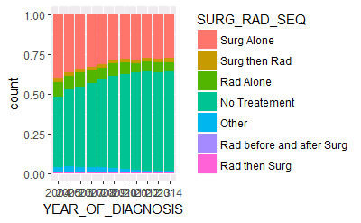

```r
data %>%
    ggplot(aes(x = YEAR_OF_DIAGNOSIS)) +
    geom_histogram(stat = "count", aes (fill = SURG_RAD_SEQ), position = "fill")
```

## Treatment by region

```r
p_table(data,
        vars = c("SURG_RAD_SEQ"),
        strata = c("FACILITY_LOCATION_F"))
```

|  | level | New England | Middle Atlantic | South Atlantic | East North Central | East South Central | West North Central | West South Central | Mountain | Pacific | p | test |
| --- | --- | --- | --- | --- | --- | --- | --- | --- | --- | --- | --- | --- |
| n |  | 6919 | 25096 | 33946 | 24847 | 10918 | 10948 | 14114 | 7742 | 17696 |  |  |
| SURG_RAD_SEQ (%) | Surg Alone | 1931 (27.9) | 7223 (28.8) | 10658 (31.4) | 6325 (25.5) | 3019 (27.7) | 3486 (31.8) | 4395 (31.1) | 1812 (23.4) | 5691 (32.2) | <0.001 |  |
|  | Surg then Rad | 153 ( 2.2) | 555 ( 2.2) | 744 ( 2.2) | 498 ( 2.0) | 158 ( 1.4) | 220 ( 2.0) | 249 ( 1.8) | 122 ( 1.6) | 553 ( 3.1) |  |  |
|  | Rad Alone | 523 ( 7.6) | 2120 ( 8.4) | 2554 ( 7.5) | 1512 ( 6.1) | 693 ( 6.3) | 929 ( 8.5) | 775 ( 5.5) | 620 ( 8.0) | 1256 ( 7.1) |  |  |
|  | No Treatement | 4094 (59.2) | 14372 (57.3) | 19364 (57.0) | 15938 (64.1) | 6957 (63.7) | 6153 (56.2) | 7972 (56.5) | 4577 (59.1) | 10046 (56.8) |  |  |
|  | Other | 215 ( 3.1) | 816 ( 3.3) | 606 ( 1.8) | 560 ( 2.3) | 86 ( 0.8) | 158 ( 1.4) | 717 ( 5.1) | 607 ( 7.8) | 142 ( 0.8) |  |  |
|  | Rad before and after Surg | 0 ( 0.0) | 0 ( 0.0) | 0 ( 0.0) | 1 ( 0.0) | 0 ( 0.0) | 0 ( 0.0) | 0 ( 0.0) | 0 ( 0.0) | 1 ( 0.0) |  |  |
|  | Rad then Surg | 3 ( 0.0) | 10 ( 0.0) | 20 ( 0.1) | 13 ( 0.1) | 5 ( 0.0) | 2 ( 0.0) | 6 ( 0.0) | 4 ( 0.1) | 7 ( 0.0) |  |  |

## Treatment by tumor size

```r
p_table(data,
        vars = c("SURG_RAD_SEQ"),
        strata = c("T_SIZE"))
```

|  | level | No Tumor | Microscopic focus | < 1 cm | 1-2 cm | 2-3 cm | 3-4 cm | 4-5 cm | 5-6 cm | >6 cm | NA_unk | p | test |
| --- | --- | --- | --- | --- | --- | --- | --- | --- | --- | --- | --- | --- | --- |
| n |  | 60 | 58 | 14837 | 44691 | 29560 | 17799 | 11271 | 6922 | 7767 | 29257 |  |  |
| SURG_RAD_SEQ (%) | Surg Alone | 20 (33.3) | 22 (37.9) | 764 ( 5.1) | 4815 (10.8) | 7750 (26.2) | 7748 (43.5) | 6549 (58.1) | 4575 (66.1) | 4770 (61.4) | 12549 (42.9) | <0.001 |  |
|  | Surg then Rad | 1 ( 1.7) | 2 ( 3.4) | 45 ( 0.3) | 187 ( 0.4) | 386 ( 1.3) | 601 ( 3.4) | 584 ( 5.2) | 410 ( 5.9) | 489 ( 6.3) | 1023 ( 3.5) |  |  |
|  | Rad Alone | 5 ( 8.3) | 0 ( 0.0) | 535 ( 3.6) | 3142 ( 7.0) | 3142 (10.6) | 1472 ( 8.3) | 472 ( 4.2) | 205 ( 3.0) | 299 ( 3.8) | 2464 ( 8.4) |  |  |
|  | No Treatement | 32 (53.3) | 34 (58.6) | 13080 (88.2) | 35319 (79.0) | 17500 (59.2) | 7539 (42.4) | 3411 (30.3) | 1580 (22.8) | 2022 (26.0) | 12432 (42.5) |  |  |
|  | Other | 2 ( 3.3) | 0 ( 0.0) | 412 ( 2.8) | 1222 ( 2.7) | 763 ( 2.6) | 428 ( 2.4) | 248 ( 2.2) | 146 ( 2.1) | 180 ( 2.3) | 769 ( 2.6) |  |  |
|  | Rad before and after Surg | 0 ( 0.0) | 0 ( 0.0) | 0 ( 0.0) | 0 ( 0.0) | 1 ( 0.0) | 0 ( 0.0) | 0 ( 0.0) | 0 ( 0.0) | 0 ( 0.0) | 1 ( 0.0) |  |  |
|  | Rad then Surg | 0 ( 0.0) | 0 ( 0.0) | 1 ( 0.0) | 6 ( 0.0) | 18 ( 0.1) | 11 ( 0.1) | 7 ( 0.1) | 6 ( 0.1) | 7 ( 0.1) | 19 ( 0.1) |  |  |

```
Ignoring unknown parameters: binwidth, bins, pad
```

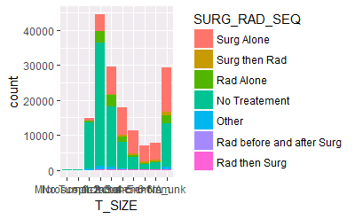

```r
data %>%
    ggplot(aes(x = T_SIZE)) +
    geom_histogram(stat = "count", aes (fill = SURG_RAD_SEQ))
```

# Tumor size by year

```r
p_table(data,
        vars = c("TUMOR_SIZE"),
        strata = c("YEAR_OF_DIAGNOSIS"))
```

|  | level | 2004 | 2005 | 2006 | 2007 | 2008 | 2009 | 2010 | 2011 | 2012 | 2013 | 2014 | p | test |
| --- | --- | --- | --- | --- | --- | --- | --- | --- | --- | --- | --- | --- | --- | --- |
| n |  | 9636 | 11098 | 12274 | 13289 | 14558 | 15828 | 15845 | 16626 | 17003 | 17727 | 18338 |  |  |
| TUMOR_SIZE (mean (sd)) |  | 329.90 (448.51) | 300.59 (436.51) | 277.65 (424.88) | 259.44 (414.40) | 218.04 (386.86) | 211.22 (381.06) | 184.55 (359.80) | 174.51 (350.62) | 165.82 (342.58) | 156.10 (332.07) | 145.15 (319.85) | <0.001 |  |

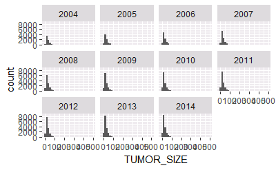

```r
data %>%
    filter(TUMOR_SIZE < 500) %>%
    ggplot(aes(x = TUMOR_SIZE)) +
    geom_histogram() +
    facet_wrap(~ YEAR_OF_DIAGNOSIS)
```

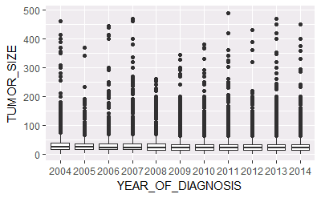

```r
data %>%
    filter(TUMOR_SIZE < 500) %>%
    ggplot(aes(x = YEAR_OF_DIAGNOSIS, y = TUMOR_SIZE)) +
    geom_boxplot()
```

# Kaplan Meier Analysis

```r
uni_var <- function(test_var, data_imp) {

        cat("_________________________________________________")
        cat("\n")
        cat("   \n##", test_var)
        cat("\n")
        cat("_________________________________________________")
        cat("\n")

        f <- as.formula(paste("Surv(DX_LASTCONTACT_DEATH_MONTHS, PUF_VITAL_STATUS == 0)",
                              as.name(test_var),
                              sep = " ~ " ))

        data_imp_2 <- deparse(substitute(data_imp))
        km_fit <- do.call("survfit", list(formula = f, data = as.name(data_imp_2)))
        print(km_fit)
        cat("\n")
        print(summary(km_fit, times = c(12, 24, 36, 48, 60, 120)))
        cat("\n")
        cat("\n")
        cat("\n")
        cat("   \n## Univariable Cox Proportional Hazard Model for: ", test_var)
        cat("\n")
        cat("\n")
        n_levels <- nlevels(data_imp[[test_var]])
        if(n_levels == 1){
                print("Only one level, no Cox model performed")
                cat("\n")
        } else {
                cox_fit <- do.call("coxph", list(formula = f, data = as.name(data_imp_2)))
                print(summary(cox_fit))
                cat("\n")

                do.call("ggforest",
                         list(model = cox_fit, data = as.name(data_imp_2)))
        }
        cat("\n")
        cat("\n")
        cat("\n")
        cat("   \n## Unadjusted Kaplan Meier Overall Survival Curve for: ", test_var)
        p <- do.call("ggsurvplot",
                     list(fit = km_fit, data = as.name(data_imp_2),
                          palette = "jco", censor = FALSE, legend = "right",
                          linetype = "strata", xlab = "Time (Months)"))
        print(p)
}
```

## All

```
_________________________________________________

## All
_________________________________________________
Call: survfit(formula = Surv(DX_LASTCONTACT_DEATH_MONTHS, PUF_VITAL_STATUS ==
    0) ~ All, data = data)

      n  events  median 0.95LCL 0.95UCL
 162222   42948     146     143     148

Call: survfit(formula = Surv(DX_LASTCONTACT_DEATH_MONTHS, PUF_VITAL_STATUS ==
    0) ~ All, data = data)

 time n.risk n.event survival  std.err lower 95% CI upper 95% CI
   12 133558   16128    0.896 0.000776        0.894        0.897
   24 114378    6595    0.850 0.000922        0.848        0.852
   36  94043    4927    0.810 0.001036        0.808        0.812
   48  76035    3966    0.773 0.001144        0.771        0.776
   60  59590    3185    0.738 0.001254        0.735        0.740
  120   9245    7541    0.574 0.002140        0.570        0.578




## Univariable Cox Proportional Hazard Model for:  All

[1] "Only one level, no Cox model performed"





## Unadjusted Kaplan Meier Overall Survival Curve for:  All
```

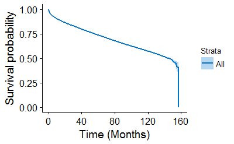

```r
uni_var(test_var = "All", data_imp = data)
```

## Facility Type

```
_________________________________________________

## FACILITY_TYPE_F
_________________________________________________
Call: survfit(formula = Surv(DX_LASTCONTACT_DEATH_MONTHS, PUF_VITAL_STATUS ==
    0) ~ FACILITY_TYPE_F, data = data)

   9996 observations deleted due to missingness
                                                  n events median 0.95LCL 0.95UCL
FACILITY_TYPE_F=Community Cancer Program      10635   3676   95.9    92.1     100
FACILITY_TYPE_F=Comprehensive Comm Ca Program 60299  19225  118.3   115.9     121
FACILITY_TYPE_F=Academic/Research Program     61165  13907  154.9   150.0      NA
FACILITY_TYPE_F=Integrated Network Ca Program 20127   5715  132.7   128.6     141

Call: survfit(formula = Surv(DX_LASTCONTACT_DEATH_MONTHS, PUF_VITAL_STATUS ==
    0) ~ FACILITY_TYPE_F, data = data)

9996 observations deleted due to missingness
                FACILITY_TYPE_F=Community Cancer Program
 time n.risk n.event survival std.err lower 95% CI upper 95% CI
   12   8032    1408    0.857 0.00353        0.850        0.864
   24   6671     573    0.793 0.00416        0.785        0.801
   36   5346     423    0.739 0.00463        0.730        0.748
   48   4145     344    0.687 0.00509        0.677        0.697
   60   3198     270    0.638 0.00554        0.627        0.649
  120    423     615    0.434 0.00874        0.417        0.451

                FACILITY_TYPE_F=Comprehensive Comm Ca Program
 time n.risk n.event survival std.err lower 95% CI upper 95% CI
   12  48191    7395    0.871 0.00140        0.868        0.874
   24  40805    2953    0.816 0.00164        0.812        0.819
   36  33135    2233    0.768 0.00183        0.764        0.771
   48  26499    1755    0.724 0.00201        0.720        0.727
   60  20585    1419    0.681 0.00219        0.677        0.685
  120   2934    3222    0.496 0.00359        0.489        0.503

                FACILITY_TYPE_F=Academic/Research Program
 time n.risk n.event survival std.err lower 95% CI upper 95% CI
   12  52161    5090    0.914 0.00115        0.912        0.916
   24  45215    2072    0.876 0.00137        0.873        0.879
```

[output cut: 36 more lines]

```
FACILITY_TYPE_FAcademic/Research Program        0.5511      1.815    0.5314    0.5715
FACILITY_TYPE_FIntegrated Network Ca Program    0.7401      1.351    0.7101    0.7714

Concordance= 0.557  (se = 0.001 )
Rsquare= 0.013   (max possible= 0.998 )
Likelihood ratio test= 1947  on 3 df,   p=0
Wald test            = 1905  on 3 df,   p=0
Score (logrank) test = 1938  on 3 df,   p=0






## Unadjusted Kaplan Meier Overall Survival Curve for:  FACILITY_TYPE_F
```

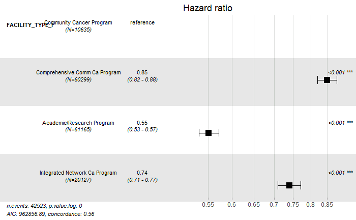

[figure not shown]

```r
uni_var(test_var = "FACILITY_TYPE_F", data_imp = data)
```

## Facility Location

```
_________________________________________________

## FACILITY_LOCATION_F
_________________________________________________
Call: survfit(formula = Surv(DX_LASTCONTACT_DEATH_MONTHS, PUF_VITAL_STATUS ==
    0) ~ FACILITY_LOCATION_F, data = data)

   9996 observations deleted due to missingness
                                           n events median 0.95LCL 0.95UCL
FACILITY_LOCATION_F=New England         6919   1992    134     127     142
FACILITY_LOCATION_F=Middle Atlantic    25096   7025    135     132     141
FACILITY_LOCATION_F=South Atlantic     33946   9470    141     136     147
FACILITY_LOCATION_F=East North Central 24847   7439    126     122     131
FACILITY_LOCATION_F=East South Central 10918   3142    133     126     140
FACILITY_LOCATION_F=West North Central 10948   2993    138     135      NA
FACILITY_LOCATION_F=West South Central 14114   3491    148     144      NA
FACILITY_LOCATION_F=Mountain            7742   1993    148     140      NA
FACILITY_LOCATION_F=Pacific            17696   4978    140     134     147

Call: survfit(formula = Surv(DX_LASTCONTACT_DEATH_MONTHS, PUF_VITAL_STATUS ==
    0) ~ FACILITY_LOCATION_F, data = data)

9996 observations deleted due to missingness
                FACILITY_LOCATION_F=New England
 time n.risk n.event survival std.err lower 95% CI upper 95% CI
   12   5797     701    0.895 0.00376        0.888        0.902
   24   5006     278    0.850 0.00442        0.842        0.859
   36   4137     230    0.808 0.00499        0.799        0.818
   48   3369     179    0.771 0.00551        0.760        0.781
   60   2620     192    0.723 0.00616        0.711        0.735
  120    433     375    0.544 0.01022        0.524        0.564

                FACILITY_LOCATION_F=Middle Atlantic
 time n.risk n.event survival std.err lower 95% CI upper 95% CI
   12  20511    2679    0.888 0.00204        0.884        0.892
   24  17436    1081    0.839 0.00241        0.834        0.844
   36  14098     857    0.795 0.00272        0.789        0.800
   48  11328     646    0.755 0.00300        0.749        0.761
   60   8713     498    0.718 0.00328        0.712        0.725
  120   1208    1172    0.548 0.00558        0.537        0.559
```

[output cut: 96 more lines]

```
FACILITY_LOCATION_FMountain              0.9313     1.0738    0.8752    0.9909
FACILITY_LOCATION_FPacific               1.0262     0.9745    0.9742    1.0809

Concordance= 0.513  (se = 0.001 )
Rsquare= 0.001   (max possible= 0.998 )
Likelihood ratio test= 118.8  on 8 df,   p=0
Wald test            = 118  on 8 df,   p=0
Score (logrank) test = 118.1  on 8 df,   p=0






## Unadjusted Kaplan Meier Overall Survival Curve for:  FACILITY_LOCATION_F
```

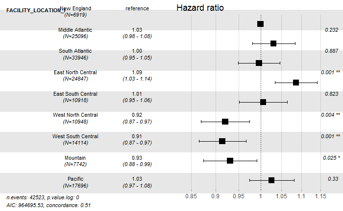

[figure not shown]

```r
uni_var(test_var = "FACILITY_LOCATION_F", data_imp = data)
```

## Facility Geography

```
_________________________________________________

## FACILITY_GEOGRAPHY
_________________________________________________
Call: survfit(formula = Surv(DX_LASTCONTACT_DEATH_MONTHS, PUF_VITAL_STATUS ==
    0) ~ FACILITY_GEOGRAPHY, data = data)

   9996 observations deleted due to missingness
                                 n events median 0.95LCL 0.95UCL
FACILITY_GEOGRAPHY=Northeast 32015   9017    135     132     139
FACILITY_GEOGRAPHY=South     48060  12961    143     140     148
FACILITY_GEOGRAPHY=Midwest   46713  13574    131     128     135
FACILITY_GEOGRAPHY=West      25438   6971    143     137     148

Call: survfit(formula = Surv(DX_LASTCONTACT_DEATH_MONTHS, PUF_VITAL_STATUS ==
    0) ~ FACILITY_GEOGRAPHY, data = data)

9996 observations deleted due to missingness
                FACILITY_GEOGRAPHY=Northeast
 time n.risk n.event survival std.err lower 95% CI upper 95% CI
   12  26308    3380    0.890 0.00179        0.886        0.893
   24  22442    1359    0.842 0.00212        0.837        0.846
   36  18235    1087    0.798 0.00239        0.793        0.802
   48  14697     825    0.758 0.00263        0.753        0.764
   60  11333     690    0.719 0.00289        0.714        0.725
  120   1641    1547    0.547 0.00490        0.537        0.556

                FACILITY_GEOGRAPHY=South
 time n.risk n.event survival std.err lower 95% CI upper 95% CI
   12  39075    4998    0.890 0.00146        0.888        0.893
   24  33446    1974    0.844 0.00173        0.840        0.847
   36  27560    1471    0.804 0.00193        0.800        0.807
   48  22245    1244    0.764 0.00214        0.760        0.769
   60  17519     925    0.730 0.00233        0.725        0.734
  120   2564    2182    0.570 0.00393        0.562        0.577

                FACILITY_GEOGRAPHY=Midwest
 time n.risk n.event survival std.err lower 95% CI upper 95% CI
   12  38554    4890    0.891 0.00147        0.888        0.894
   24  33008    2076    0.841 0.00175        0.838        0.844
```

[output cut: 36 more lines]

```
FACILITY_GEOGRAPHYMidwest    1.0029     0.9971    0.9765    1.0299
FACILITY_GEOGRAPHYWest       0.9739     1.0268    0.9439    1.0048

Concordance= 0.503  (se = 0.001 )
Rsquare= 0   (max possible= 0.998 )
Likelihood ratio test= 23.36  on 3 df,   p=3.404e-05
Wald test            = 23.28  on 3 df,   p=3.525e-05
Score (logrank) test = 23.29  on 3 df,   p=3.517e-05






## Unadjusted Kaplan Meier Overall Survival Curve for:  FACILITY_GEOGRAPHY
```

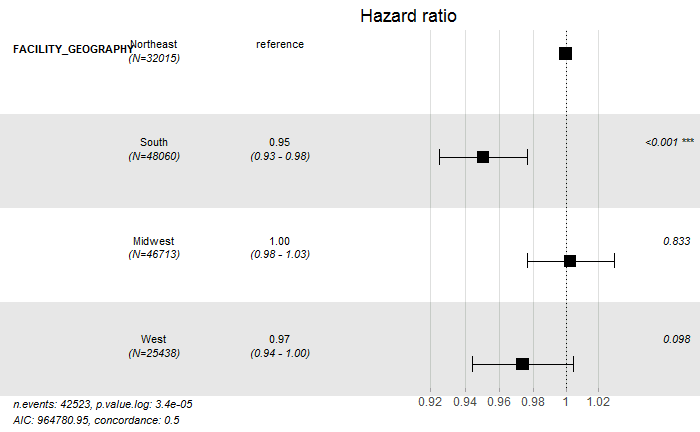

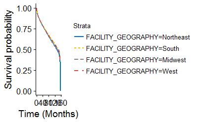

```r
uni_var(test_var = "FACILITY_GEOGRAPHY", data_imp = data)
```

## Age Group

```
_________________________________________________

## AGE_F
_________________________________________________
Call: survfit(formula = Surv(DX_LASTCONTACT_DEATH_MONTHS, PUF_VITAL_STATUS ==
    0) ~ AGE_F, data = data)

   34 observations deleted due to missingness
                   n events median 0.95LCL 0.95UCL
AGE_F=(0,54]   42567   2859     NA      NA      NA
AGE_F=(54,64]  33259   4612  157.3      NA      NA
AGE_F=(64,74]  35653   8814  139.4   136.3   142.3
AGE_F=(74,100] 50709  26655   55.3    54.4    56.2

Call: survfit(formula = Surv(DX_LASTCONTACT_DEATH_MONTHS, PUF_VITAL_STATUS ==
    0) ~ AGE_F, data = data)

34 observations deleted due to missingness
                AGE_F=(0,54]
 time n.risk n.event survival  std.err lower 95% CI upper 95% CI
   12  37923     959    0.976 0.000755        0.975        0.978
   24  33753     444    0.964 0.000935        0.963        0.966
   36  28794     328    0.954 0.001079        0.952        0.956
   48  24126     236    0.946 0.001204        0.943        0.948
   60  19570     231    0.936 0.001359        0.933        0.938
  120   3649     602    0.883 0.002643        0.878        0.889

                AGE_F=(54,64]
 time n.risk n.event survival std.err lower 95% CI upper 95% CI
   12  28997    1659    0.948 0.00125        0.945        0.950
   24  25340     735    0.923 0.00152        0.920        0.926
   36  21264     534    0.902 0.00174        0.898        0.905
   48  17582     407    0.883 0.00194        0.879        0.887
   60  14088     339    0.864 0.00215        0.860        0.868
  120   2399     857    0.765 0.00409        0.757        0.773

                AGE_F=(64,74]
 time n.risk n.event survival std.err lower 95% CI upper 95% CI
   12  29967    3132    0.908 0.00156        0.905        0.911
   24  25754    1336    0.866 0.00187        0.862        0.870
```

[output cut: 36 more lines]

```
AGE_F(64,74]      4.195    0.23837     4.022     4.376
AGE_F(74,100]    11.619    0.08606    11.178    12.078

Concordance= 0.722  (se = 0.001 )
Rsquare= 0.179   (max possible= 0.998 )
Likelihood ratio test= 31929  on 3 df,   p=0
Wald test            = 25749  on 3 df,   p=0
Score (logrank) test = 34517  on 3 df,   p=0






## Unadjusted Kaplan Meier Overall Survival Curve for:  AGE_F
```

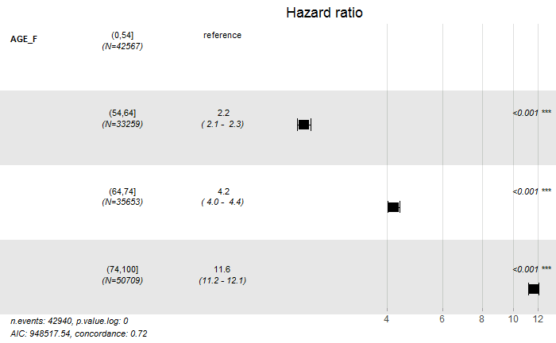

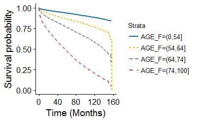

```r
uni_var(test_var = "AGE_F", data_imp = data)
```

## Age Group

```
_________________________________________________

## AGE_40
_________________________________________________
Call: survfit(formula = Surv(DX_LASTCONTACT_DEATH_MONTHS, PUF_VITAL_STATUS ==
    0) ~ AGE_40, data = data)

   34 observations deleted due to missingness
                     n events median 0.95LCL 0.95UCL
AGE_40=(0,40]    11169    484     NA      NA      NA
AGE_40=(40,100] 151019  42456    136     135     138

Call: survfit(formula = Surv(DX_LASTCONTACT_DEATH_MONTHS, PUF_VITAL_STATUS ==
    0) ~ AGE_40, data = data)

34 observations deleted due to missingness
                AGE_40=(0,40]
 time n.risk n.event survival std.err lower 95% CI upper 95% CI
   12   9956     161    0.985 0.00118        0.983        0.987
   24   8828      76    0.977 0.00148        0.974        0.980
   36   7516      44    0.972 0.00167        0.968        0.975
   48   6287      43    0.966 0.00190        0.962        0.969
   60   5050      46    0.958 0.00222        0.953        0.962
  120    948     105    0.921 0.00447        0.912        0.930

                AGE_40=(40,100]
 time n.risk n.event survival  std.err lower 95% CI upper 95% CI
   12 123579   15963    0.889 0.000826        0.888        0.891
   24 105532    6517    0.840 0.000979        0.839        0.842
   36  86512    4882    0.799 0.001098        0.796        0.801
   48  69737    3922    0.759 0.001210        0.757        0.762
   60  54532    3139    0.722 0.001323        0.719        0.724
  120   8296    7436    0.549 0.002239        0.545        0.554





## Univariable Cox Proportional Hazard Model for:  AGE_40

```

[output cut: 12 more lines]

```
               exp(coef) exp(-coef) lower .95 upper .95
AGE_40(40,100]     7.488     0.1335     6.846      8.19

Concordance= 0.532  (se = 0.001 )
Rsquare= 0.025   (max possible= 0.998 )
Likelihood ratio test= 4110  on 1 df,   p=0
Wald test            = 1940  on 1 df,   p=0
Score (logrank) test = 2690  on 1 df,   p=0






## Unadjusted Kaplan Meier Overall Survival Curve for:  AGE_40
```

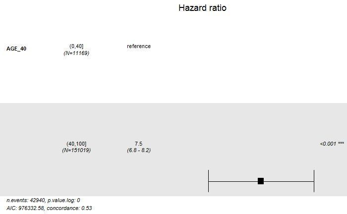

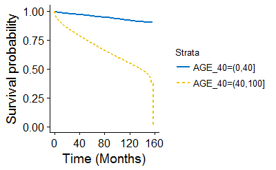

```r
uni_var(test_var = "AGE_40", data_imp = data)
```

## Gender

```
_________________________________________________

## SEX_F
_________________________________________________
Call: survfit(formula = Surv(DX_LASTCONTACT_DEATH_MONTHS, PUF_VITAL_STATUS ==
    0) ~ SEX_F, data = data)

                  n events median 0.95LCL 0.95UCL
SEX_F=Male    41745  13364    120     118     123
SEX_F=Female 120477  29584    150     148      NA

Call: survfit(formula = Surv(DX_LASTCONTACT_DEATH_MONTHS, PUF_VITAL_STATUS ==
    0) ~ SEX_F, data = data)

                SEX_F=Male
 time n.risk n.event survival std.err lower 95% CI upper 95% CI
   12  33014    5468    0.863 0.00173        0.859        0.866
   24  27837    2061    0.806 0.00201        0.803        0.810
   36  22575    1496    0.760 0.00223        0.755        0.764
   48  17978    1183    0.717 0.00243        0.712        0.721
   60  13914     925    0.676 0.00263        0.671        0.681
  120   2016    2065    0.500 0.00430        0.492        0.509

                SEX_F=Female
 time n.risk n.event survival  std.err lower 95% CI upper 95% CI
   12 100544   10660    0.907 0.000855        0.906        0.909
   24  86541    4534    0.865 0.001024        0.863        0.867
   36  71468    3431    0.828 0.001158        0.826        0.830
   48  58057    2783    0.793 0.001285        0.790        0.795
   60  45676    2260    0.759 0.001415        0.756        0.762
  120   7229    5476    0.599 0.002461        0.594        0.604





## Univariable Cox Proportional Hazard Model for:  SEX_F

Call:
coxph(formula = Surv(DX_LASTCONTACT_DEATH_MONTHS, PUF_VITAL_STATUS ==
```

[output cut: 9 more lines]

```
            exp(coef) exp(-coef) lower .95 upper .95
SEX_FFemale    0.7093       1.41    0.6949    0.7239

Concordance= 0.537  (se = 0.001 )
Rsquare= 0.006   (max possible= 0.998 )
Likelihood ratio test= 1036  on 1 df,   p=0
Wald test            = 1085  on 1 df,   p=0
Score (logrank) test = 1096  on 1 df,   p=0






## Unadjusted Kaplan Meier Overall Survival Curve for:  SEX_F
```

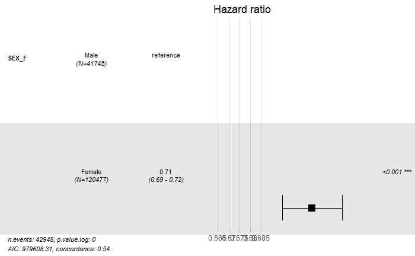

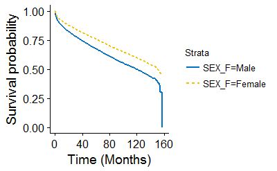

```r
uni_var(test_var = "SEX_F", data_imp = data)
```

## RACE_F

```
_________________________________________________

## RACE_F
_________________________________________________
Call: survfit(formula = Surv(DX_LASTCONTACT_DEATH_MONTHS, PUF_VITAL_STATUS ==
    0) ~ RACE_F, data = data)

                      n events median 0.95LCL 0.95UCL
RACE_F=White     132725  36120    142     140     146
RACE_F=Black      20028   5168     NA     142      NA
RACE_F=Other/Unk   4486    722     NA      NA      NA
RACE_F=Asian       4983    938     NA     150      NA

Call: survfit(formula = Surv(DX_LASTCONTACT_DEATH_MONTHS, PUF_VITAL_STATUS ==
    0) ~ RACE_F, data = data)

                RACE_F=White
 time n.risk n.event survival  std.err lower 95% CI upper 95% CI
   12 109509   13436    0.894 0.000863        0.893        0.896
   24  93891    5518    0.847 0.001024        0.845        0.849
   36  77195    4165    0.807 0.001152        0.805        0.809
   48  62429    3321    0.769 0.001270        0.767        0.772
   60  48987    2699    0.733 0.001391        0.730        0.736
  120   7711    6460    0.565 0.002352        0.560        0.569

                RACE_F=Black
 time n.risk n.event survival std.err lower 95% CI upper 95% CI
   12  16325    2005    0.895 0.00223        0.890        0.899
   24  13869     834    0.847 0.00265        0.842        0.852
   36  11411     590    0.808 0.00297        0.802        0.814
   48   9249     494    0.770 0.00329        0.764        0.777
   60   7167     376    0.736 0.00360        0.729        0.743
  120    993     818    0.583 0.00625        0.571        0.595

                RACE_F=Other/Unk
 time n.risk n.event survival std.err lower 95% CI upper 95% CI
   12   3666     302    0.928 0.00400        0.920        0.936
   24   3176      95    0.902 0.00467        0.893        0.912
   36   2652      71    0.881 0.00523        0.870        0.891
   48   2178      57    0.860 0.00577        0.849        0.871
```

[output cut: 33 more lines]

```
RACE_FOther/Unk    0.5849      1.710    0.5433    0.6296
RACE_FAsian        0.7193      1.390    0.6741    0.7674

Concordance= 0.51  (se = 0.001 )
Rsquare= 0.002   (max possible= 0.998 )
Likelihood ratio test= 344.4  on 3 df,   p=0
Wald test            = 297.1  on 3 df,   p=0
Score (logrank) test = 302.6  on 3 df,   p=0






## Unadjusted Kaplan Meier Overall Survival Curve for:  RACE_F
```

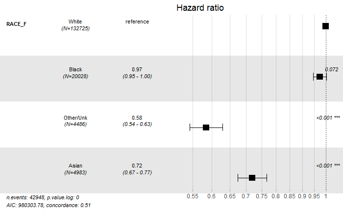

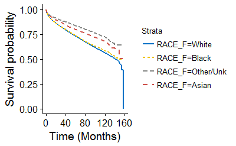

```r
uni_var(test_var = "RACE_F", data_imp = data)
```

## Hispanic

```
_________________________________________________

## HISPANIC
_________________________________________________
Call: survfit(formula = Surv(DX_LASTCONTACT_DEATH_MONTHS, PUF_VITAL_STATUS ==
    0) ~ HISPANIC, data = data)

                      n events median 0.95LCL 0.95UCL
HISPANIC=No      143329  38588    142     140     146
HISPANIC=Yes       9714   1674     NA      NA      NA
HISPANIC=Unknown   9179   2686    148     139      NA

Call: survfit(formula = Surv(DX_LASTCONTACT_DEATH_MONTHS, PUF_VITAL_STATUS ==
    0) ~ HISPANIC, data = data)

                HISPANIC=No
 time n.risk n.event survival  std.err lower 95% CI upper 95% CI
   12 118146   14473    0.894 0.000830        0.893        0.896
   24 100996    5957    0.847 0.000986        0.845        0.849
   36  82734    4455    0.807 0.001109        0.805        0.809
   48  66562    3587    0.769 0.001225        0.767        0.772
   60  51894    2870    0.733 0.001344        0.730        0.735
  120   7980    6717    0.565 0.002299        0.561        0.570

                HISPANIC=Yes
 time n.risk n.event survival std.err lower 95% CI upper 95% CI
   12   7863     710    0.921 0.00284        0.916        0.927
   24   6657     272    0.888 0.00339        0.881        0.894
   36   5368     191    0.860 0.00384        0.852        0.867
   48   4276     145    0.834 0.00428        0.826        0.843
   60   3329     103    0.812 0.00468        0.803        0.821
  120    441     237    0.705 0.00870        0.688        0.722

                HISPANIC=Unknown
 time n.risk n.event survival std.err lower 95% CI upper 95% CI
   12   7549     945    0.892 0.00331        0.886        0.899
   24   6725     366    0.848 0.00388        0.840        0.855
   36   5941     281    0.811 0.00429        0.803        0.820
   48   5197     234    0.778 0.00463        0.769        0.787
   60   4367     212    0.744 0.00498        0.734        0.754
```

[output cut: 21 more lines]

```
HISPANICYes        0.6664      1.501    0.6346    0.6998
HISPANICUnknown    0.9607      1.041    0.9238    0.9990

Concordance= 0.509  (se = 0.001 )
Rsquare= 0.002   (max possible= 0.998 )
Likelihood ratio test= 300.9  on 2 df,   p=0
Wald test            = 265.6  on 2 df,   p=0
Score (logrank) test = 269.2  on 2 df,   p=0






## Unadjusted Kaplan Meier Overall Survival Curve for:  HISPANIC
```

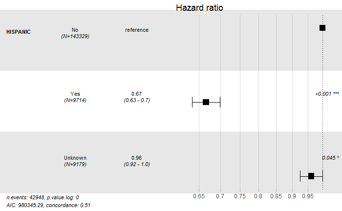

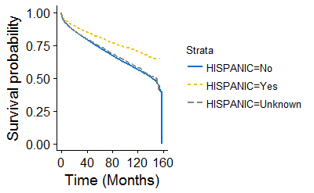

```r
uni_var(test_var = "HISPANIC", data_imp = data)
```

## Insurance Status

```
_________________________________________________

## INSURANCE_F
_________________________________________________
Call: survfit(formula = Surv(DX_LASTCONTACT_DEATH_MONTHS, PUF_VITAL_STATUS ==
    0) ~ INSURANCE_F, data = data)

                                 n events median 0.95LCL 0.95UCL
INSURANCE_F=Private          60796   6989  157.3      NA      NA
INSURANCE_F=None              6103    810     NA      NA      NA
INSURANCE_F=Medicaid          9410   1637     NA   152.2      NA
INSURANCE_F=Medicare         80866  32354   84.5    83.4    85.8
INSURANCE_F=Other Government  1719    324  153.1   153.1      NA
INSURANCE_F=Unknown           3328    834  149.3   144.3      NA

Call: survfit(formula = Surv(DX_LASTCONTACT_DEATH_MONTHS, PUF_VITAL_STATUS ==
    0) ~ INSURANCE_F, data = data)

                INSURANCE_F=Private
 time n.risk n.event survival  std.err lower 95% CI upper 95% CI
   12  53649    2486    0.957 0.000839        0.956        0.959
   24  47516    1091    0.937 0.001022        0.935        0.939
   36  40405     770    0.921 0.001161        0.918        0.923
   48  33647     631    0.905 0.001298        0.902        0.908
   60  27227     527    0.889 0.001442        0.887        0.892
  120   4923    1335    0.809 0.002685        0.804        0.815

                INSURANCE_F=None
 time n.risk n.event survival std.err lower 95% CI upper 95% CI
   12   4891     323    0.942 0.00315        0.936        0.948
   24   4162     126    0.916 0.00381        0.909        0.923
   36   3422     102    0.892 0.00441        0.883        0.900
   48   2745      69    0.872 0.00492        0.862        0.881
   60   2084      64    0.849 0.00556        0.838        0.860
  120    305     119    0.752 0.01052        0.732        0.773

                INSURANCE_F=Medicaid
 time n.risk n.event survival std.err lower 95% CI upper 95% CI
   12   7773     668    0.925 0.00280        0.919        0.930
   24   6565     254    0.893 0.00335        0.886        0.899
```

[output cut: 57 more lines]

```
INSURANCE_FOther Government     1.884     0.5308     1.685     2.106
INSURANCE_FUnknown              2.220     0.4504     2.066     2.385

Concordance= 0.653  (se = 0.001 )
Rsquare= 0.1   (max possible= 0.998 )
Likelihood ratio test= 17109  on 5 df,   p=0
Wald test            = 13942  on 5 df,   p=0
Score (logrank) test = 16333  on 5 df,   p=0






## Unadjusted Kaplan Meier Overall Survival Curve for:  INSURANCE_F
```

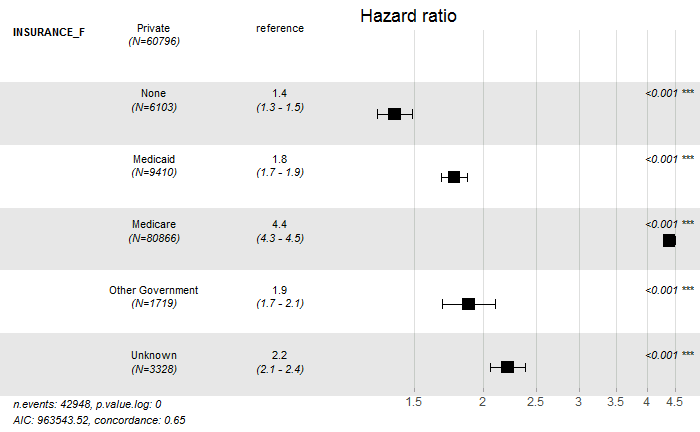

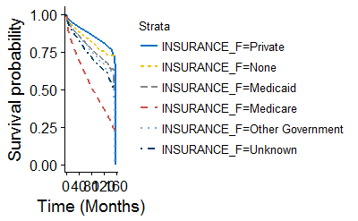

```r
uni_var(test_var = "INSURANCE_F", data_imp = data)
```

## Income

```
_________________________________________________

## INCOME_F
_________________________________________________
Call: survfit(formula = Surv(DX_LASTCONTACT_DEATH_MONTHS, PUF_VITAL_STATUS ==
    0) ~ INCOME_F, data = data)

   1588 observations deleted due to missingness
                               n events median 0.95LCL 0.95UCL
INCOME_F=Less than $38,000 27752   7998    134     131     139
INCOME_F=$38,000 - $47,999 36718  10186    138     134     141
INCOME_F=$48,000 - $62,999 43555  11370    145     140     150
INCOME_F=$63,000 +         52609  12592    151     150      NA

Call: survfit(formula = Surv(DX_LASTCONTACT_DEATH_MONTHS, PUF_VITAL_STATUS ==
    0) ~ INCOME_F, data = data)

1588 observations deleted due to missingness
                INCOME_F=Less than $38,000
 time n.risk n.event survival std.err lower 95% CI upper 95% CI
   12  22608    3067    0.884 0.00196        0.881        0.888
   24  19191    1233    0.834 0.00232        0.829        0.839
   36  15792     908    0.792 0.00259        0.787        0.797
   48  12775     771    0.750 0.00286        0.744        0.755
   60  10009     535    0.715 0.00309        0.709        0.722
  120   1492    1383    0.541 0.00524        0.531        0.552

                INCOME_F=$38,000 - $47,999
 time n.risk n.event survival std.err lower 95% CI upper 95% CI
   12  30014    3796    0.892 0.00166        0.888        0.895
   24  25626    1570    0.843 0.00197        0.839        0.847
   36  21048    1167    0.802 0.00222        0.797        0.806
   48  17070     907    0.764 0.00244        0.760        0.769
   60  13458     772    0.727 0.00267        0.721        0.732
  120   2122    1816    0.555 0.00450        0.546        0.564

                INCOME_F=$48,000 - $62,999
 time n.risk n.event survival std.err lower 95% CI upper 95% CI
   12  36082    4172    0.900 0.00147        0.897        0.903
   24  30943    1777    0.854 0.00176        0.850        0.857
```

[output cut: 36 more lines]

```
INCOME_F$48,000 - $62,999    0.8865      1.128    0.8615    0.9122
INCOME_F$63,000 +            0.8036      1.244    0.7814    0.8265

Concordance= 0.523  (se = 0.001 )
Rsquare= 0.002   (max possible= 0.997 )
Likelihood ratio test= 283.1  on 3 df,   p=0
Wald test            = 282.2  on 3 df,   p=0
Score (logrank) test = 282.9  on 3 df,   p=0






## Unadjusted Kaplan Meier Overall Survival Curve for:  INCOME_F
```

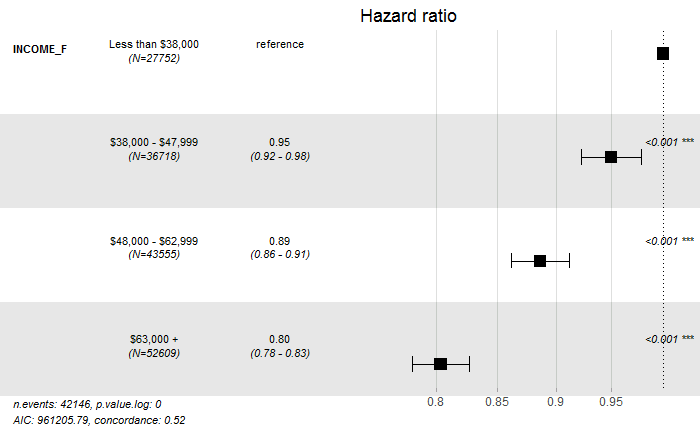

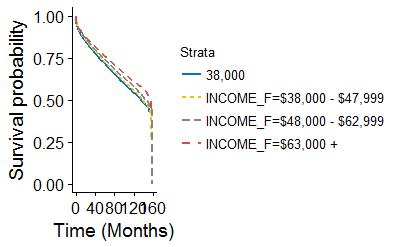

```r
uni_var(test_var = "INCOME_F", data_imp = data)
```

## Education

```
_________________________________________________

## EDUCATION_F
_________________________________________________
Call: survfit(formula = Surv(DX_LASTCONTACT_DEATH_MONTHS, PUF_VITAL_STATUS ==
    0) ~ EDUCATION_F, data = data)

   1514 observations deleted due to missingness
                             n events median 0.95LCL 0.95UCL
EDUCATION_F=21% or more  27761   7364    144     137      NA
EDUCATION_F=13 - 20.9%   41058  11189    141     138     148
EDUCATION_F=7 - 12.9%    51591  13775    143     140     149
EDUCATION_F=Less than 7% 40298   9840    151     148      NA

Call: survfit(formula = Surv(DX_LASTCONTACT_DEATH_MONTHS, PUF_VITAL_STATUS ==
    0) ~ EDUCATION_F, data = data)

1514 observations deleted due to missingness
                EDUCATION_F=21% or more
 time n.risk n.event survival std.err lower 95% CI upper 95% CI
   12  22543    2859    0.892 0.00192        0.888        0.895
   24  19200    1134    0.845 0.00227        0.840        0.849
   36  15762     854    0.804 0.00255        0.799        0.809
   48  12719     714    0.765 0.00282        0.759        0.770
   60   9952     488    0.733 0.00306        0.727        0.739
  120   1415    1222    0.568 0.00538        0.558        0.579

                EDUCATION_F=13 - 20.9%
 time n.risk n.event survival std.err lower 95% CI upper 95% CI
   12  33507    4245    0.891 0.00157        0.888        0.895
   24  28495    1769    0.842 0.00187        0.839        0.846
   36  23309    1283    0.801 0.00210        0.797        0.806
   48  18837     992    0.764 0.00231        0.760        0.769
   60  14729     816    0.728 0.00253        0.723        0.733
  120   2259    1930    0.564 0.00423        0.556        0.572

                EDUCATION_F=7 - 12.9%
 time n.risk n.event survival std.err lower 95% CI upper 95% CI
   12  42672    5136    0.896 0.00137        0.893        0.899
   24  36642    2075    0.851 0.00163        0.848        0.854
```

[output cut: 36 more lines]

```
EDUCATION_F7 - 12.9%       0.9739     1.0268    0.9468    1.0019
EDUCATION_FLess than 7%    0.8698     1.1496    0.8440    0.8965

Concordance= 0.517  (se = 0.001 )
Rsquare= 0.001   (max possible= 0.997 )
Likelihood ratio test= 152.6  on 3 df,   p=0
Wald test            = 149.8  on 3 df,   p=0
Score (logrank) test = 150  on 3 df,   p=0






## Unadjusted Kaplan Meier Overall Survival Curve for:  EDUCATION_F
```

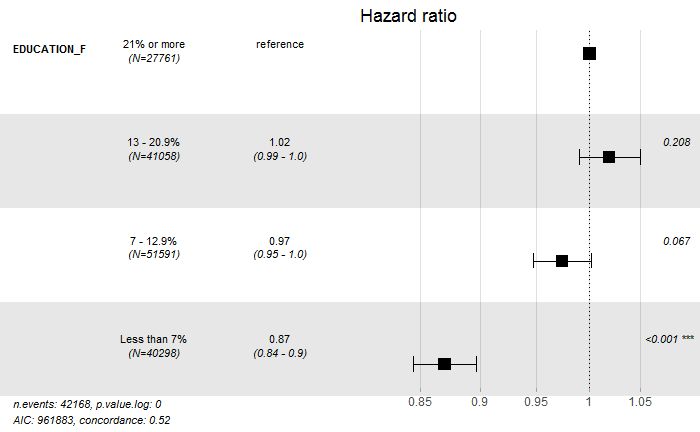

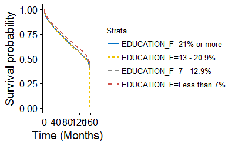

```r
uni_var(test_var = "EDUCATION_F", data_imp = data)
```

## Urban/Rural

```
_________________________________________________

## U_R_F
_________________________________________________
Call: survfit(formula = Surv(DX_LASTCONTACT_DEATH_MONTHS, PUF_VITAL_STATUS ==
    0) ~ U_R_F, data = data)

   4948 observations deleted due to missingness
                 n events median 0.95LCL 0.95UCL
U_R_F=Metro 135234  35587    147     144     149
U_R_F=Urban  19546   5068    144     139      NA
U_R_F=Rural   2494    703    129     124      NA

Call: survfit(formula = Surv(DX_LASTCONTACT_DEATH_MONTHS, PUF_VITAL_STATUS ==
    0) ~ U_R_F, data = data)

4948 observations deleted due to missingness
                U_R_F=Metro
 time n.risk n.event survival  std.err lower 95% CI upper 95% CI
   12 111709   13285    0.897 0.000845        0.896        0.899
   24  95763    5497    0.851 0.001005        0.849        0.853
   36  78709    4142    0.812 0.001132        0.809        0.814
   48  63619    3330    0.774 0.001251        0.772        0.777
   60  49817    2636    0.739 0.001370        0.736        0.742
  120   7625    6205    0.576 0.002346        0.572        0.581

                U_R_F=Urban
 time n.risk n.event survival std.err lower 95% CI upper 95% CI
   12  16056    1898    0.898 0.00221        0.894        0.903
   24  13749     749    0.855 0.00262        0.849        0.860
   36  11354     544    0.818 0.00294        0.812        0.824
   48   9202     438    0.784 0.00324        0.778        0.790
   60   7258     370    0.749 0.00356        0.742        0.756
  120   1232     985    0.576 0.00612        0.565        0.589

                U_R_F=Rural
 time n.risk n.event survival std.err lower 95% CI upper 95% CI
   12   2059     257    0.892 0.00636        0.880        0.905
   24   1769     103    0.846 0.00750        0.831        0.860
   36   1467      73    0.808 0.00836        0.792        0.825
```

[output cut: 22 more lines]

```
U_R_FUrban    0.9785     1.0220    0.9501     1.008
U_R_FRural    1.0503     0.9521    0.9747     1.132

Concordance= 0.502  (se = 0.001 )
Rsquare= 0   (max possible= 0.997 )
Likelihood ratio test= 3.94  on 2 df,   p=0.1398
Wald test            = 3.95  on 2 df,   p=0.1386
Score (logrank) test = 3.95  on 2 df,   p=0.1385






## Unadjusted Kaplan Meier Overall Survival Curve for:  U_R_F
```

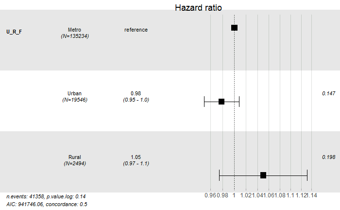

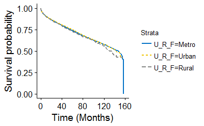

```r
uni_var(test_var = "U_R_F", data_imp = data)
```